# Building the Mechanism

Bivalent, Exhaustive Mediators for Front-Door Identification with Bayesian SEMs

Nathaniel Forde

Data Science @ PandaDoc

and Open Source Contributor @ PyMC

2026-11-12

## Preliminaries

**Who am I?**

- I’m a **data scientist** at **PandaDoc**
  - Bayesian statistician,
  - Reformed philosopher and logician.
- Website: https://nathanielf.github.io/

[figure not shown]

Link to my website

**Code or it didn’t Happen**

The companion notebook, with every model and sensitivity analysis in this talk, is [here](https://github.com/NathanielF/NathanielF.github.io/blob/master/talks/cdsm_2026_frontdoor/notebook/frontdoor_sem_sensitivity.ipynb). The worked example is drawn from the SEM chapter of *Bayesian Causal Inference* (Vincent & Forde, in preparation).

## The Pitch

The front-door criterion identifies a causal effect **through unmeasured confounding**, with no instrument required.

So why does almost nobody use it?

- It asks the mediator to carry **everything**: every directed path from $X$ to $Y$.
- Any effect that **leaks** around the mediator breaks identification.
- Read as a demand on a single observed node, almost no real mediator qualifies.

**The argument:** the mediator should be **built, not found**. Identification is a piece of information architecture.

## Agenda

**Act I: The Demand of the Front Door.** Why a single mediator node almost never qualifies, and why identification is an architecture rather than a discovery

**Act II: Building the Mechanism.** A bivalent mediator set for job satisfaction, encoded in two matrices of a Bayesian SEM

**Act III: Auditing the Architecture.** Relaxing the zeros, recovering the parameters, and springing a leak

# Act I: The Demand of the Front Door

## The Front-Door Criterion

Pearl (1995): $M$ identifies the effect of $X$ on $Y$ when

1. $M$ intercepts **every** directed path from $X$ to $Y$
2. There is no unblocked back-door path from $X$ to $M$
3. Every back-door path from $M$ to $Y$ is blocked by $X$

Then, despite the unmeasured $U$:

$$P(y \mid do(x)) = \sum_m P(m \mid x) \sum_{x'} P(y \mid m, x') P(x')$$

Two well-identified pieces, $X \to M$ and $M \to Y \mid X$, are chained together.

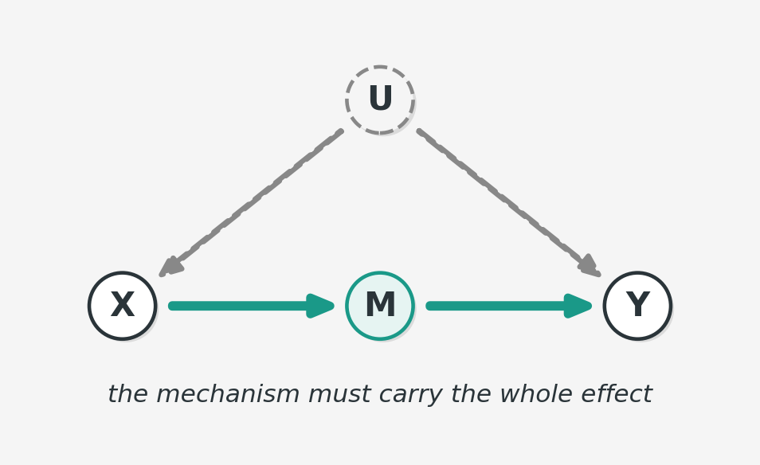

## Why It Is Rarely Used

- A bare DAG node is a **single indicator**: loading fixed at 1, no measurement error.
- Asked to exhaust a pathway in social, marketing or organisational data, it fails.
- The pieces exist: Pearl admits a **mediator set**; Kuroki (2000) and Kuroki & Cai (2004) treat front-door in linear SEMs; multi-indicator latents are standard practice.

**What is missing is the construction step.**

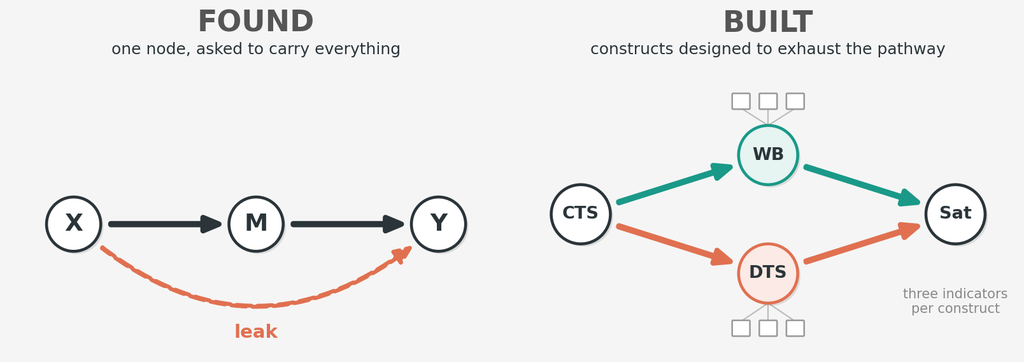

## Identification as Information Architecture

Every credible design decides **where variation is allowed to flow**. None of these plans is found in the data.

| Design | Unwanted variation is… | The argument you owe |
| --- | --- | --- |
| **Propensity score weighting** | *rebalanced*: reweighting builds a pseudo-population where treatment is independent of the observed covariates | every confounder is observed, and overlap holds |
| **Double ML** | *residualised away*: flexible nuisance models partial it out of $T$ and $Y$ | every confounder is observed |
| **Mundlak device** | *absorbed by group means*: cluster means of the covariates soak up the correlation between group effects and treatment | the unobserved confounding lives at the group level |
| **Control-function IV** | *modelled explicitly*: the first-stage residual $\hat v$ enters the outcome equation | relevance and exclusion of the instrument |
| **Front-door SEM** | *quarantined*: confounding may live in $\text{Cov}(\zeta_X, \zeta_Y)$, and **nowhere else** | the mechanism is exhaustive and unconfounded |

A structural equation model is a blueprint of permitted covariances. The front-door design is one floor plan: **the effect must walk through the mechanism, the confounding must stay in its room.**

# Act II: Building the Mechanism

## The Job Satisfaction Constructs

Houghton & Jinkerson (2007): 12 indicators, 4 constructs; 263 observations simulated from their published correlations.

- **CTS**, constructive thought strategies (treatment): `EBA`, `ST`, `MI`
- **DTS**, dysfunctional thought: `DA1`–`DA3`
- **WB**, well-being: `UF1`, `UF2`, `FOR`
- **Satisfaction** (outcome): `JW1`–`JW3`

The mechanism is **bivalent**: CTS *suppresses* a negative construct and *raises* a positive one.

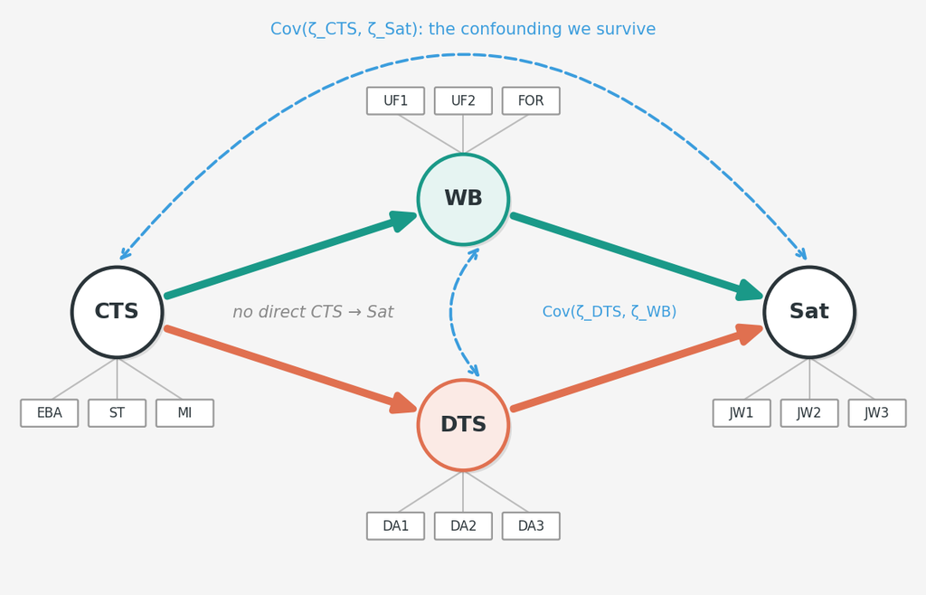

**The front-door claim:** these two routes *exhaust* CTS’s influence: a premise to argue, not a finding.

## One Covariance Form, Two Matrices

Both models share the marginal covariance

$$\Sigma_y = \Lambda(I - \color{blue}{B})^{-1}\color{blue}{\Psi_\zeta}(I - \color{blue}{B})^{-\top}\Lambda^\top + \Psi$$

and the mechanism is encoded entirely in $\color{blue}{B}$ and $\color{blue}{\Psi_\zeta}$.

$$\color{blue}{B} = \begin{bmatrix} \overbrace{0}^{Sat} & \overbrace{\beta_{sw}}^{WB} & \overbrace{\beta_{sd}}^{DTS} & \overbrace{\color{red}{0}}^{CTS} \\ 0 & 0 & \color{red}{0} & \beta_{wc} \\ 0 & 0 & 0 & \beta_{dc} \\ 0 & 0 & 0 & 0 \end{bmatrix}$$

Direct edge CTS → Sat and the path DTS → WB are removed.

$$\color{blue}{\Psi_\zeta} = \begin{bmatrix} \psi_{s} & 0 & 0 & \color{blue}{\psi_{sc}} \\ 0 & \psi_{w} & \color{blue}{\psi_{wd}} & 0 \\ 0 & \color{blue}{\psi_{wd}} & \psi_{d} & 0 \\ \color{blue}{\psi_{sc}} & 0 & 0 & \psi_{c} \end{bmatrix}$$

Exactly two covariances stay free: **treatment–outcome confounding** $\psi_{sc}$, and **structure inside the mediator set** $\psi_{wd}$.

Every other zero is the formal content of *“the mechanism explains everything.”*

## The Mechanism in Code

```python
FRONTDOOR_PATHS = [
    ("dysfunctional", "constructive"),  # CTS -> DTS
    ("well being", "constructive"),     # CTS -> WB
    ("satisfaction", "well being"),     # WB  -> Sat
    ("satisfaction", "dysfunctional"),  # DTS -> Sat
]
FRONTDOOR_COVS = [
    ("satisfaction", "constructive"),   # confounding we survive
    ("well being", "dysfunctional"),    # inside the mechanism
]
with pm.Model(coords=coords) as frontdoor_model:
    Lambda, Psi = measurement_model(sample_df)
    Psi_zeta = make_Psi_zeta(FRONTDOOR_COVS)
    betas = pmd.Normal("mu_betas", 0, 1, dims="frontdoor_paths")
    B = set_edges(pt.zeros((4, 4)), FRONTDOOR_PATHS, betas.values)

    inv = pt.linalg.solve(pt.eye(4) - B, pt.eye(4))
    Sigma_y = Lambda @ inv @ Psi_zeta @ inv.T @ Lambda.T + Psi
    pm.MvNormal("likelihood", mu=0, cov=Sigma_y, observed=observed_data)
```

- The **edge list** is the mechanism.
- The **permitted covariances** are the walls.
- Everything else is a zero we have to defend.
- The total effect is read off $(I - B)^{-1}$.

## The Payoff

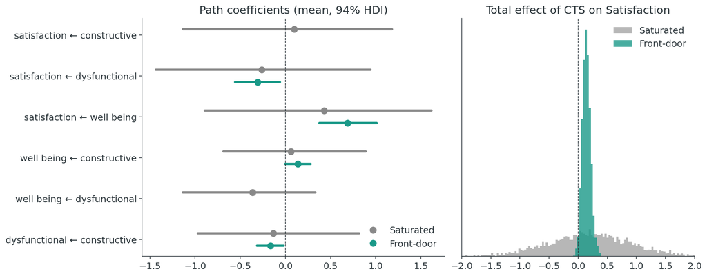

|  | Total effect CTS → Sat | 94% HDI | Posterior SD | SRMR |
| --- | --- | --- | --- | --- |
| **Saturated** | +0.19 | [−1.25, +1.62] | 0.77 | 0.054 |
| **Front-door** | +0.14 | [+0.01, +0.27] | 0.07 | 0.053 |

The saturated model is **not identified**: its interval is mostly prior. The front-door model is identified, and its interval **just** excludes zero. Global fit is unchanged: the restrictions trade one-for-one for identification, so **fit cannot test them**.

## What the Second Mediator Buys

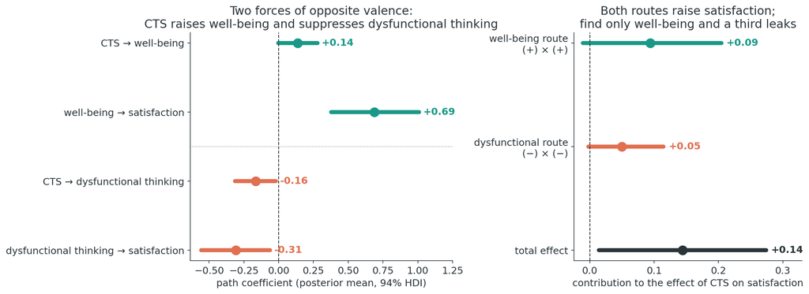

- CTS **raises** a positive force (well-being: +0.14 × +0.69 = **+0.09**) and **suppresses** a negative one (dysfunctional thinking: −0.16 × −0.31 = **+0.05**).
- *Find* only well-being: the suppression route becomes a **leak**, and the front door **misses about a third (35%)** of the effect.

Two different gains from building:

- **Several indicators per construct** handle *measurement error*.
- **Several constructs, of opposite valence**, handle *exhaustiveness*: that is what closes the pathway.

# Act III: Auditing the Architecture

## Relaxing the Zeros

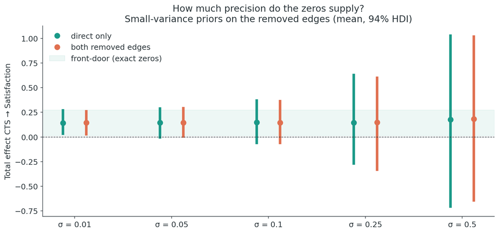

Muthén & Asparouhov (2012): replace each exact zero with $\text{Normal}(0, \sigma)$ and watch the conclusion.

- The **mean barely moves** (≈ 0.14–0.18): the data are nearly silent about the direct edge.
- The **interval does all the moving**: at $\sigma = 0.05$ the HDI already reaches zero; at $\sigma = 0.5$ it is almost as wide as the saturated model’s.
- Re-admitting DTS → WB **changes nothing**. One zero, CTS → Sat, carries the precision.

## Simulating from the Mechanism

### Can the model recover itself?

```python
# Fix every parameter at the fitted values,
# plus a direct leak the front-door model forbids
with pm.do(generator, {**truth, "leak": [delta]}):
    y = pm.sample_prior_predictive(draws=1)[
        "prior"]["likelihood"]  # one synthetic survey, n = 263
# Condition a fresh front-door model on it
with pm.observe(build_frontdoor(observed=None),
                {"likelihood": y}):
    idata = pm.sample()
```

With $\delta = 0$ the model **recovers what generated the data**: the total-effect HDI covers the truth in 8 / 8 replicates. But the estimates are noisy at $n = 263$, because the CTS → mediator paths are small.

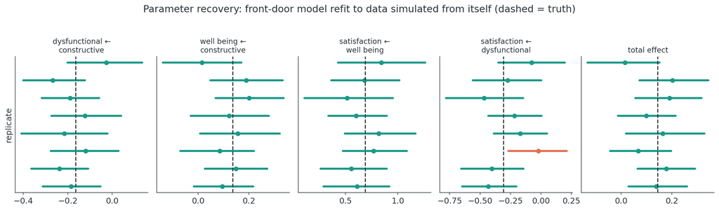

## Springing a Leak

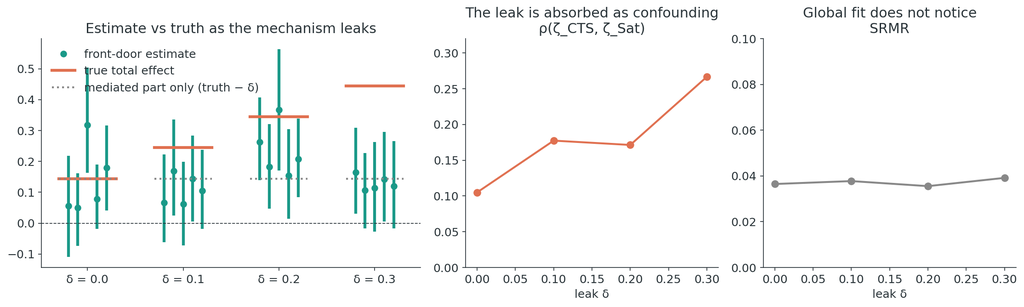

- In a linear SEM a front door recovers only what flows **through** its mediators, so a leak of size $\delta$ biases it by exactly $-\delta$ (dotted line). The simulations track this, noisily: five replicates per $\delta$; coverage of the true effect falls to zero by $\delta = 0.3$.
- The leak is **absorbed as confounding**: $\rho(\zeta_{CTS}, \zeta_{Sat})$ rises from 0.10 to 0.27, and **SRMR never moves**.

## A Design Pattern for People Analytics

### Same DAG, easier premises to defend

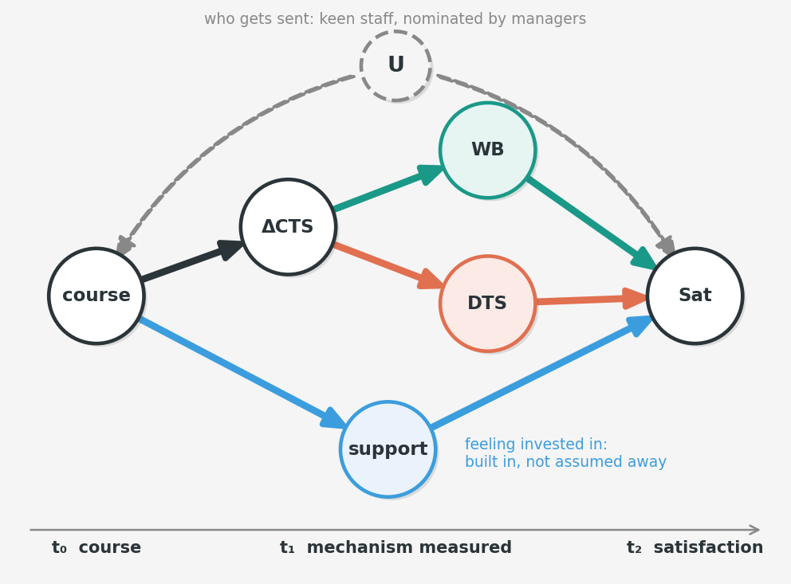

**The recipe, applied**

1. **Build**: after a thought-strategy course, measure the change in CTS, well-being, dysfunctional thinking and perceived support.
2. **Argue**: the course reaches satisfaction only through them. Who gets *sent* is the confounding the design survives.
3. **Encode**: the argument as zeros in $B$ and $\Psi_\zeta$.
4. **Audit**: relax the zeros, simulate leaks, recover parameters.
- If enrolment can be **randomised**, just compare the groups. The front door is for selected enrolment, the usual HR case.
- Given the DAG, the cross-sectional SEM is **already** a causal argument: conditioning stands in for intervention. A dated course makes the DAG’s premises **easier to defend**: time order, and a named confounder.

## Conclusion

### Identification is Built

> “SEM is an inference engine that takes in two inputs, qualitative causal assumptions and empirical data, and derives two logical consequences of these inputs: quantitative causal conclusions and statistical measures of fit for the testable implications of the assumptions… **Fitting the data does not ”prove” the causal assumptions, but it makes them tentatively more plausible.**”

– Bollen & Pearl, *Eight Myths about Causality and Structural Equation Models*

- The front-door restrictions are not even *tentatively* tested by fit: they are paid for in identification, one-for-one.
- So the warrant for the estimate lives in the **construction**: the choice of constructs, their measurement, and the argument that they exhaust the pathway.
- Bayesian SEMs make that warrant **auditable**: soften the zeros, simulate the leaks, and report how much of the answer the architecture supplies.

“The mediator is not found.

It is built.”

## Resources

**Resources**

- Companion notebook: [github.com/NathanielF/…/frontdoor_sem_sensitivity.ipynb](https://github.com/NathanielF/NathanielF.github.io/blob/master/talks/cdsm_2026_frontdoor/notebook/frontdoor_sem_sensitivity.ipynb)
- PyMC: pymc.io
- Pearl (1995), “Causal Diagrams for Empirical Research,” *Biometrika*
- Kuroki (2000), “Selection of Post-Treatment Variables for Estimating Total Effect,” *J. Japan Stat. Soc.*
- Kuroki & Cai (2004), “Selection of Identifiability Criteria for Total Effects,” *UAI*
- Muthén & Asparouhov (2012), “Bayesian SEM: A More Flexible Representation of Substantive Theory,” *Psych. Methods*
- Houghton & Jinkerson (2007), “Constructive Thought Strategies and Job Satisfaction,” *J. Business & Psychology*
- Bollen & Pearl (2013), “Eight Myths about Causality and SEMs”

[figure not shown]

Bayesian Causal Inference (Vincent & Forde), coming soon

See: https://bayesian-causal-inference.com/

## Backup: Where the Confounding Lives

Every zero in $\Psi_\zeta$ carries a reason. The argument partitions the unmeasured causes by **what they act on**:

| Unmeasured source | Acts on | In the model |
| --- | --- | --- |
| **Workplace-specific**: manager, job quality, coaching culture | CTS *and* satisfaction | the one free covariance $\psi_{sc}$: the confounding the design survives |
| **General disposition**: temperament, trait affect | well-being, dysfunctional thinking → satisfaction | absorbed by the mediators; no direct path to a domain-specific outcome |
| **The premise**: CTS is a *learnt strategy*, not a trait |  | no covariance between CTS and either mediator |

**What this argument does not cover:**

- a **behavioural route**: constructive thinking → performance → rewards → satisfaction, which bypasses affect entirely;
- **shared measurement**: one self-report survey, so method variance is a candidate common cause of everything.

The remedy for both is the recipe’s: measure the route (performance, perceived support) and build it into the mechanism.

## Backup: “The Confounding Is Small. Why Not Just Regress?”

The front-door model estimates the treatment–outcome confounding as

$$\rho(\zeta_{CTS}, \zeta_{Sat}) = 0.09 \quad [-0.05,\ 0.22]$$

(89% interval). It is small, and its interval includes zero.

- The front door does not **need** confounding. It is **robust** to it: the estimate is valid whether $\rho$ is zero or not.
- A plain regression is valid only if $\rho$ **is** zero, which is the assumption the front door avoids.

**And $\rho$ is not a clean measurement**

The leak simulation showed that a direct path is **absorbed into $\rho$**: as the leak grew, $\rho$ rose from 0.10 to 0.27 while fit stayed flat.

So $\rho$ is estimated *on the assumption* of no direct path. The data cannot separate confounding from leakage, which is the talk’s point: **fit cannot arbitrate; the construction must.**

## Backup: Where This Sits in the Front-Door Literature

| Work | Contribution | Relation to this talk |
| --- | --- | --- |
| Pearl (1995), *Biometrika* | The front-door criterion; the mediator may be a **set** | the starting point |
| Kuroki (2000); Kuroki & Cai (2004) | Front-door identification and variable selection in **linear SEMs** | the algebra we use |
| Glynn & Kashin (2018), *JASA* | **Bias formulas** for front-door adjustment when its assumptions fail; job-training application | the relaxation curve is a Bayesian analogue: how the answer moves as a direct path is allowed |
| Fulcher, Shpitser, Marealle & Tchetgen Tchetgen (2020), *JRSS-B* | **Generalised front door**: with a direct effect, the front-door formula identifies an *indirect* effect, under an additional cross-world assumption | reinterprets the leak result: bias of $-\delta$ means the estimate is the mediated effect |
| Bellemare, Bloem & Wexler (2024), *Oxford Bull. Econ. Stat.* | “The Paper of How”: front door is rarely used because a valid mechanism is **hard to find** | the problem this talk answers by **building** the mechanism |

**This talk’s contribution:** not new identification theory, but the **construction step** (a mediator set of multi-indicator, opposite-valence constructs) and a Bayesian **audit** of what each zero supplies.